# L01 Introduction

David Cheng

April 2, 2019

```r
# Load package(s) - We will do this together
library(tidyverse)
library(ggstance)
library(skimr)
library(janitor)
```

# Dataset

We’ll be using data from the [**lego** package](https://github.com/seankross/lego) which is already in the `/data` subdirectory, along with many other processed datasets, as part of the zipped folder for this lab.

### Task 1

Download and install [R Software](https://cran.rstudio.com/).  
**Completed**

### Task 2

1. Download and install [RStudio](https://www.rstudio.com/products/rstudio/download4/).
2. Open RStudio and ensure it and R have been properly installed.
3. Go to **Tools** > **Global Options** and change the two indicated settings below and click **Apply**. — See L01_introduction.html.  
   **Completed**

### Task 3

Install the following packages:

- `tidyverse`
- `ggstance`
- `skimr`  
  **Completed**

### Task 4

1. Download `data_vis_labs.zip` from Canvas.
2. Unzip the file and place the unzipped `data_vis_labs` directory where you would like to keep all of your lab work for this course.
3. Open RStudio and create a project folder for this *exsisting directory*.
4. Appropriately rename `template_L01.Rmd` for submission (e.g. *Kuper_Arend_L01.Rmd*).
5. Compile the *_L01.Rmd file with Cmd/Ctrl + Shift + K.  
   **Completed**

### Task 5

Optional: It is always handy to have a versatile text editor and I would suggest downloading [Sublime Text](https://www.sublimetext.com/). It is free to use.  
**Completed**

# Exercise 1

### Inspect the data

The **lego** package provides a helpful dataset some interesting variables. Let’s take a quick look at the data.

```r
load(file = "data/legosets.rda")

legosets <- legosets %>%
  clean_names()

skim_with(numeric = list(hist = NULL),
          integer = list(hist = NULL))

legosets %>%
  skim()
```

```
## Skim summary statistics
##  n obs: 6172
##  n variables: 14
##
## ── Variable type:character ──────────────────────────────────────────────────────────────────────────────────────────────
##      variable missing complete    n min max empty n_unique
##  availability       0     6172 6172   6  21     0        8
##     image_url       0     6172 6172  46  58     0     6172
##   item_number       0     6172 6172   1  13     0     5854
##          name       0     6172 6172   2  73     0     5519
##     packaging       0     6172 6172   3  21     0       14
##      subtheme       0     6172 6172   0  32  2206      358
##         theme       0     6172 6172   4  28     0      115
##
## ── Variable type:integer ────────────────────────────────────────────────────────────────────────────────────────────────
##     variable missing complete    n    mean     sd   p0  p25  p50     p75
##  minifigures    2672     3500 6172    2.85   2.72    1    1    2    4
##       pieces     112     6060 6172  215.17 356.2     0   30   82  256.25
##         year       0     6172 6172 2004.71   8.91 1971 2000 2006 2012
##  p100
##    32
##  5922
##  2015
##
## ── Variable type:numeric ────────────────────────────────────────────────────────────────────────────────────────────────
##  variable missing complete    n  mean    sd   p0   p25   p50   p75   p100
##  cad_msrp    4190     1982 6172 46.34 58.46 2.99 12.99 24.99 54.99 789.99
##  eur_msrp    4399     1773 6172 35.98 46.61 0     9.99 19.99 39.99 699.99
##  gbp_msrp    1980     4192 6172 23.45 31.93 0     5.99 12.99 29.99 509.99
##  usd_msrp     355     5817 6172 27.9  39.32 0     6    14.99 34.99 789.99
```

### Price per year

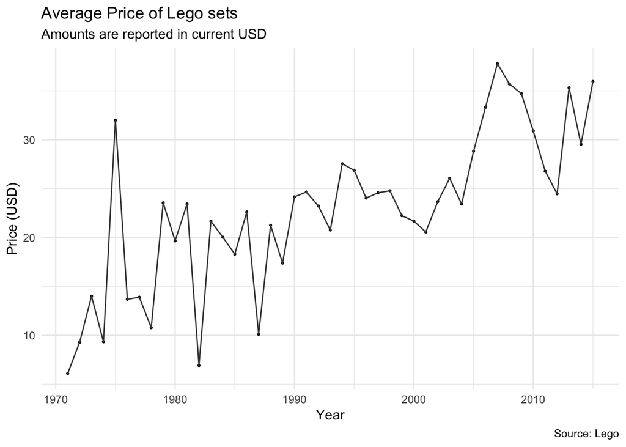

```r
avg_price_per_year <- legosets %>%
  filter(!is.na(usd_msrp)) %>%
  group_by(year) %>%
  summarise(price = mean(usd_msrp))

avg_price_per_year %>%
  ggplot(aes(x = year, y = price)) +
    geom_point(size = .5) +
    geom_line(color = "#444444", size = .5) +
    labs(x = "Year",
         y = "Price (USD)",
         title = "Average Price of Lego sets",
         subtitle = "Amounts are reported in current USD",
         caption = "Source: Lego") +
    theme_minimal()
```

> The average price of lego sets goes up over time.

### Pieces per year

Next, let’s look at how the number of pieces per set has changed over time. Because Duplo sets are much smaller (since they’re designed for toddlers), we’ll make a special indicator variable for them.

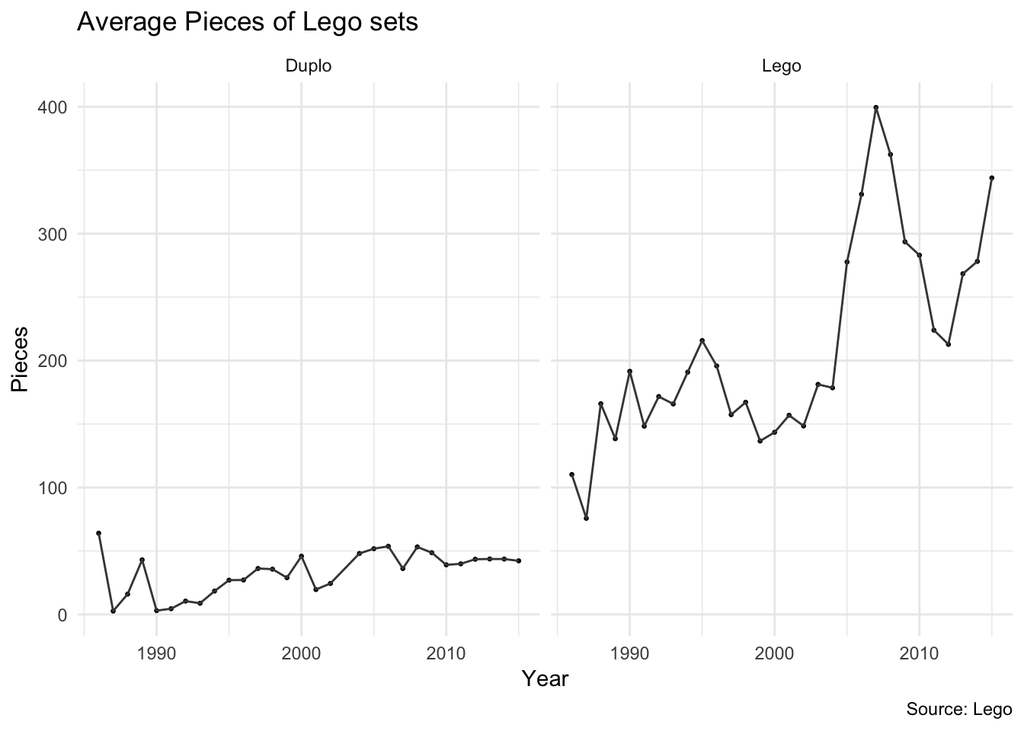

```r
pieces_per_year <- legosets %>%
  filter(year >= 1986) %>%
  filter(!is.na(pieces)) %>%
  mutate(duplo = ifelse(theme == "Duplo", "Duplo", "Lego")) %>%
  group_by(year, duplo) %>%
  summarise(pieces = mean(pieces),
            num_sets = n()) %>%
  arrange(year)

pieces_per_year %>%
  ggplot(aes(x = year, y = pieces)) +
    geom_point(size = .5) +
    geom_line(color = "#444444", size = .5) +
    facet_wrap(~duplo) +
    labs(x = "Year",
         y = "Pieces",
         title = "Average Pieces of Lego sets",
         caption = "Source: Lego") +
    theme_minimal()
```

> Duplo sets hover around 5 to 50 pieces per set with a slow increase in the number of pieces over time. All non Duplo sets have seen an increase in the average number of pieces per set over time

### LEGO set themes

In the 1990s, [LEGO began partnering with famous brands and franchises](https://www.cnbc.com/2018/04/27/lego-marketing-strategy-made-it-world-favorite-toy-brand.html) to boost its own sales. First, let’s see how many different “themes” LEGO now offers:

```r
legosets %>%
  distinct(theme)
```

```
## # A tibble: 115 x 1
##    theme
##    <chr>
##  1 Advanced Models
##  2 Duplo
##  3 Juniors
##  4 Classic
##  5 Architecture
##  6 Minecraft
##  7 Ideas
##  8 Friends
##  9 Legends of Chima
## 10 Star Wars
## # … with 105 more rows
```

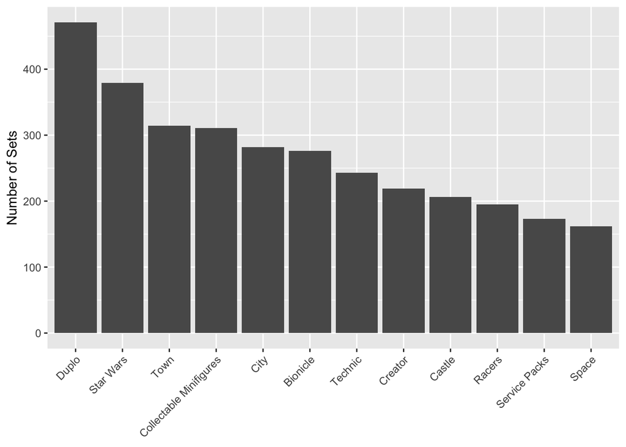

```r
theme_counts <- legosets %>%
  count(theme, sort = TRUE) %>%
  mutate(theme = fct_inorder(theme, ordered = TRUE))

theme_counts %>%
  filter(n > 150) %>%
  ggplot(aes(x = theme, y = n)) +
  geom_bar(stat = "identity") +
  theme(axis.text.x = element_text(angle = 45, hjust = 1)) +
  labs(x = NULL,
       y = "Number of Sets")
```

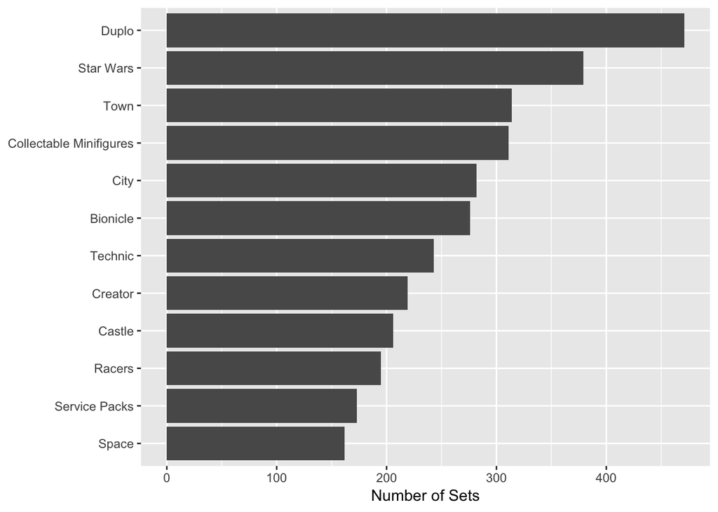

```r
theme_counts %>%
  filter(n > 150) %>%
  ggplot(aes(x = n, y = fct_rev(theme))) +
  geom_barh(stat = "identity") +
  labs(x = "Number of Sets",
       y = NULL)
```

> Duplo has the most number of sets followed by Star Wars, Town, and Coleectable Minifigures.